# Fundamentals of ggplot2

## Aesthetic mappings

The aesthetic mappings take properties of the data and use them to influence visual characteristics, such as position, colour, size, shape, or transparency. Each visual characteristic can thus encode an aspect of the data and be used to convey information.

All aesthetics for a plot are specified in the `aes()` function call (later in this tutorial you will see that each geom layer can have its own aes specification).

```r
# add a mapping from the class of the cars to a colour characteristic
ggplot(mpg, aes(x = displ, y = hwy, colour = class)) +
  geom_point()
```

[output not shown]

Note that ‘aesthetics’ in ggplot refers to WHAT is plotted, now HOW it is plotted, unlike the word’s usual meaning. Using the `aes()` function will cause the visual to be based on the *data* specified in the argument. For example, using `aes(colour = "blue")` won’t cause the geometry’s colour to be ‘blue’, but will instead cause the visual to be mapped from the vector `c("blue")` — as if we only had a single type of engine that happened to be called ‘blue’. If you wish to apply an aesthetic property to an entire geometry, you can set that property as an argument to the geom method, OUTSIDE of the `aes()` call:

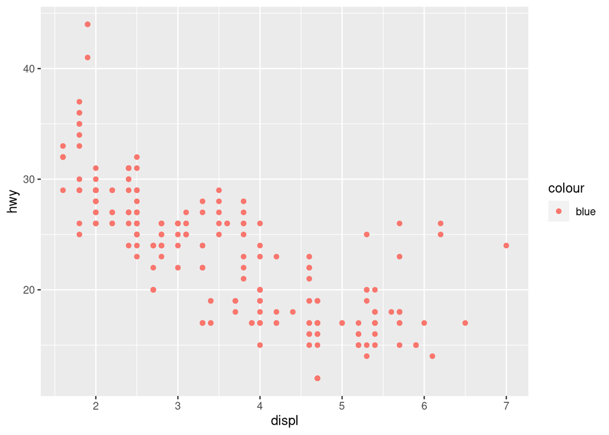

```r
# illustrate the common mistake of trying to specify a colour within the aes() function
ggplot(mpg, aes(x = displ, y = hwy, colour = "blue")) +
  geom_point()
```

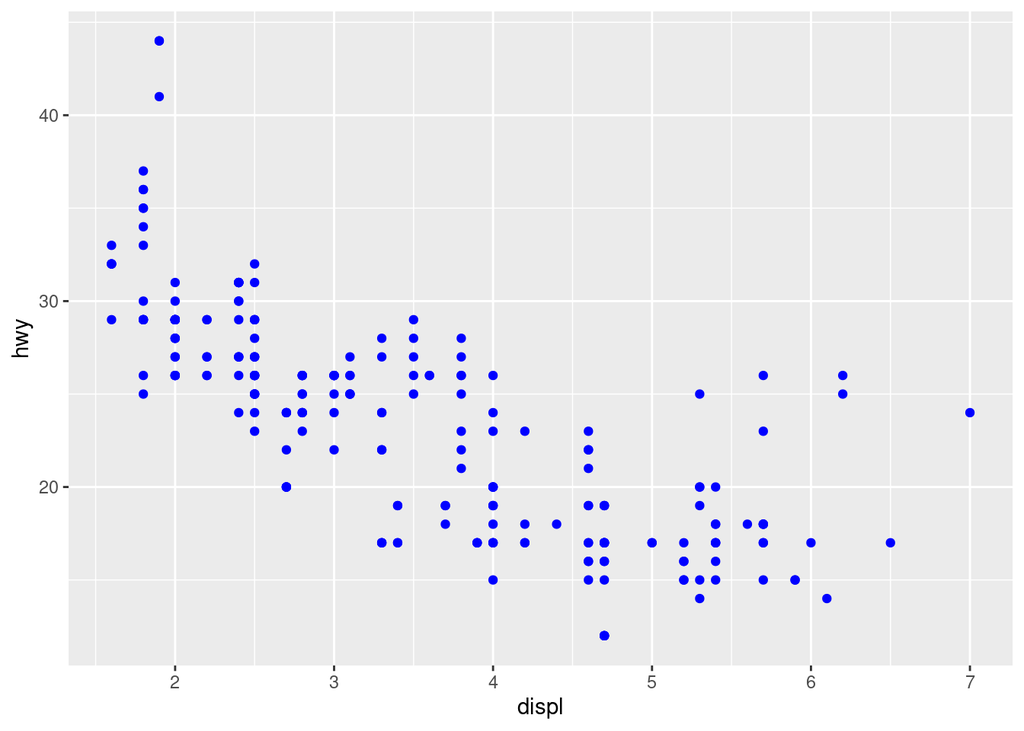

```r
# here is the correct way
ggplot(mpg, aes(x = displ, y = hwy)) +
  geom_point(colour = "blue")
```

### Exercise:

1. Make a scatterplot of the relationship between the city and highway mileage of each car. Colour all the points red.

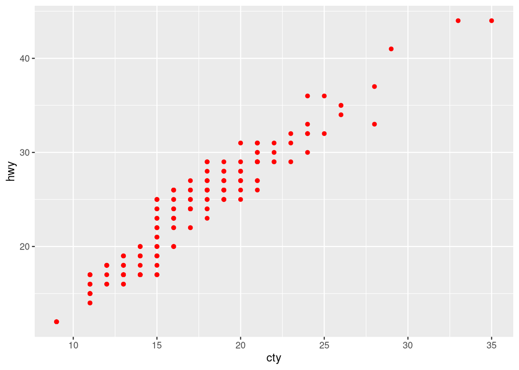

```r
# YOUR CODE HERE
ggplot(mpg, aes(x = cty, y = hwy)) +
  geom_point(colour = "red")
```

2. Now, colour the points in your scatterplot by the number of cylinders each car has.

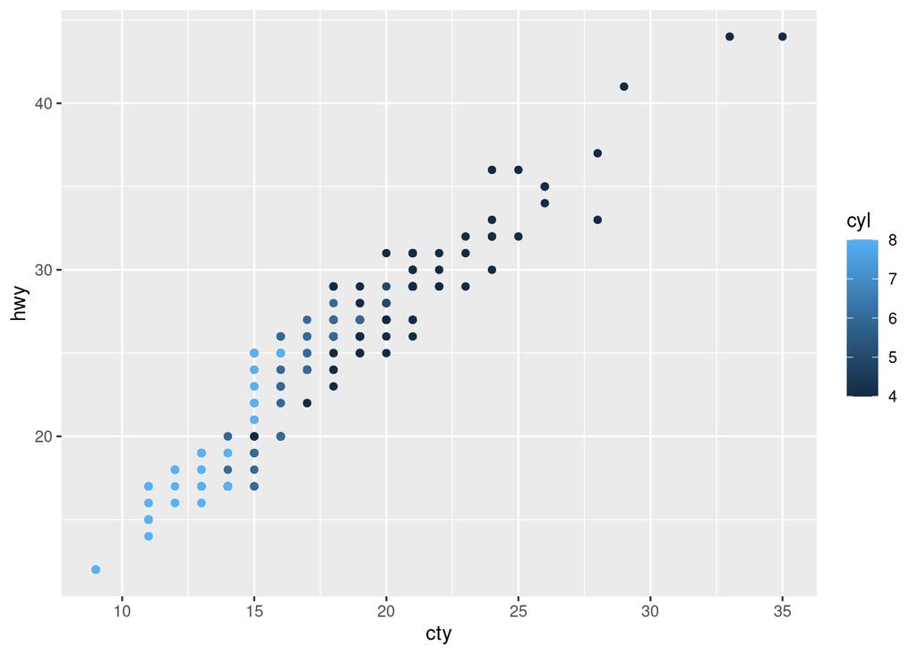

```r
# YOUR CODE HERE
ggplot(mpg, aes(x = cty, y = hwy, colour = cyl)) +
  geom_point()
```

## Specifying geometries

Building on these basics, ggplot2 can be used to build almost any kind of plot you may want. These plots are declared using functions.

The most obvious distinction between plots is what geometric objects (geoms) they include. ggplot2 supports a number of different types of geoms, including:

- `geom_point()`
- `geom_line()`
- `geom_smooth()`
- `geom_bar()`
- `geom_boxplot()`
- `geom_histogram()`
- `geom_polygon()`
- `geom_map()`

Each of these geometries will leverage the aesthetic mappings supplied. For example, you can map data to the location, colour, and shape of a geom_point (e.g., points can be circles or squares), or you can map data to the linetype of a geom_line (e.g., solid or dotted).

Most geoms require an x and y mapping as a bare minimum.

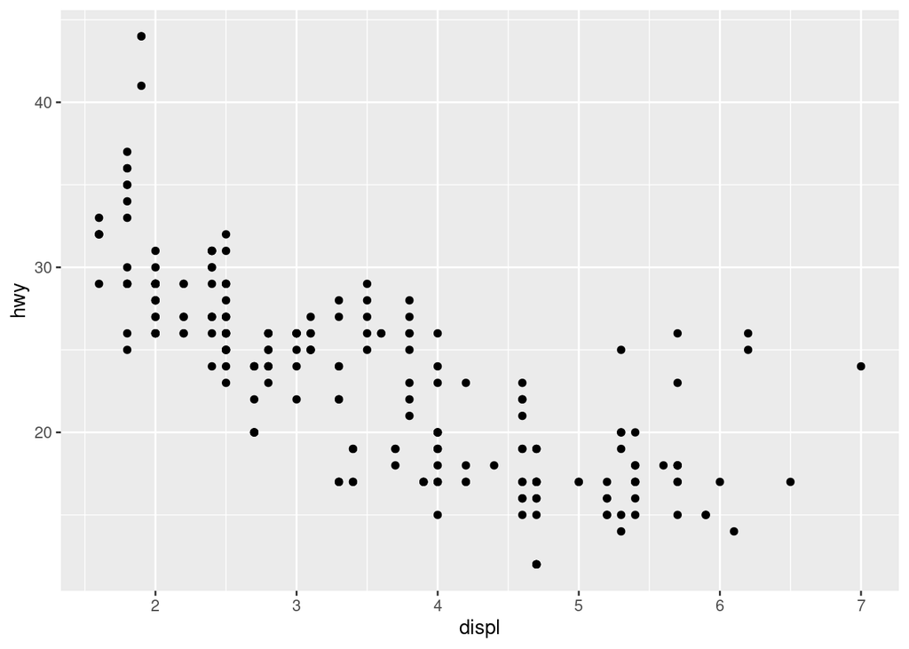

```r
# x and y mapping needed for geom_point and geom_smooth
ggplot(mpg, aes(x = displ, y = hwy)) +
  geom_point()
```

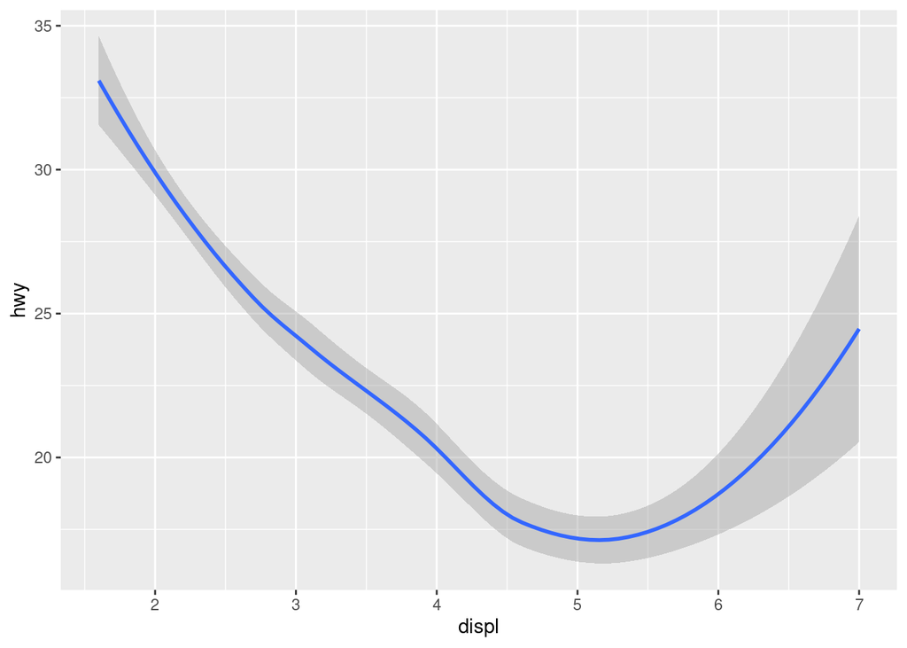

```r
ggplot(mpg, aes(x = displ, y = hwy)) +
  geom_smooth()
```

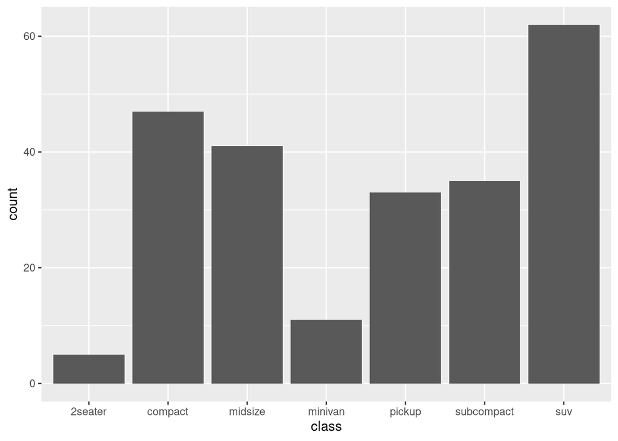

```r
# no y mapping needed for geom_bar and geom_histogram
ggplot(data = mpg, aes(x = class)) +
  geom_bar()
```

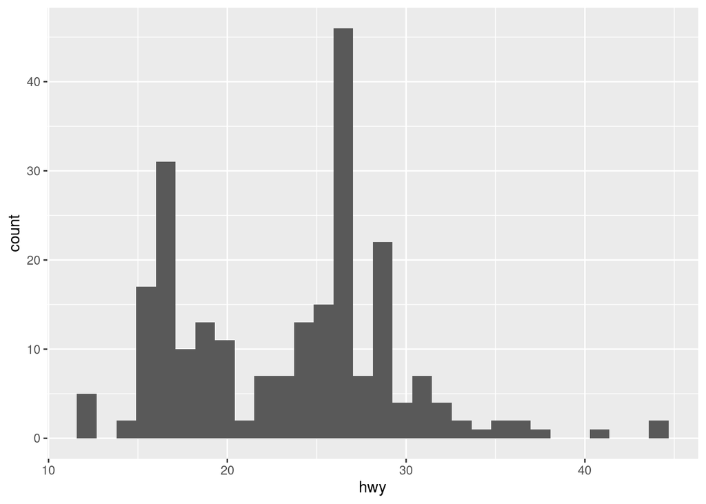

```r
ggplot(data = mpg, aes(x = hwy)) +
  geom_histogram()
```

### Exercise:

1. Create a box-and-whisker plot of the engine displacement of the different drive types (front, rear, or 4wd).

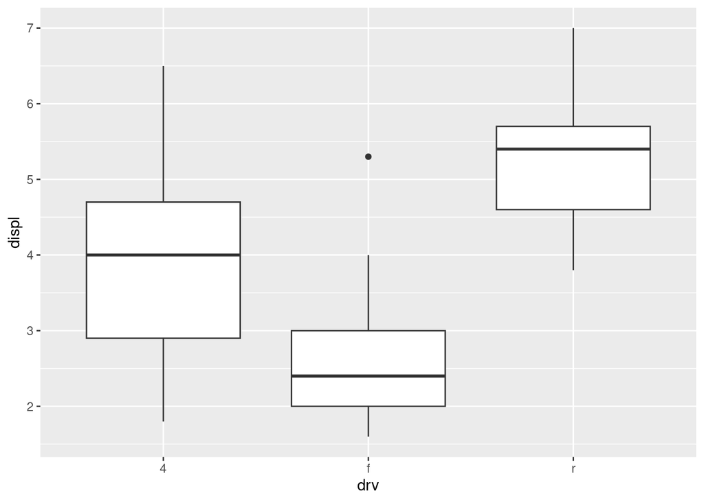

```r
# YOUR CODE HERE
ggplot(mpg, aes(x = drv, y = displ)) +
  geom_boxplot()
```

2. Create a box-and-whisker plot of the engine displacement of the different engine types (cylinders). What happens if your x variable is numeric? How might we fix that?

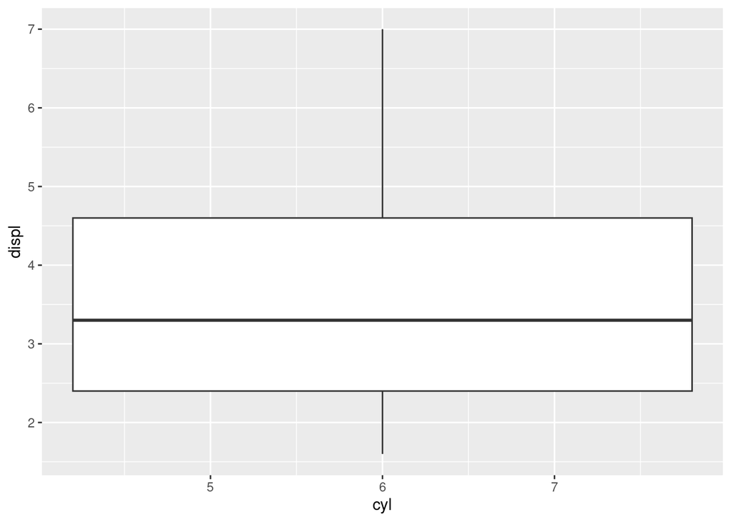

```r
# YOUR CODE HERE
ggplot(mpg, aes(x = cyl, y = displ)) +
  geom_boxplot()
```

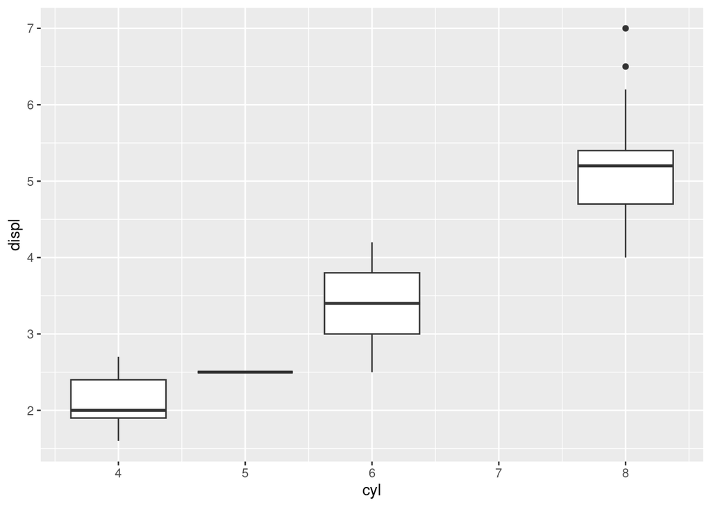

```r
ggplot(mpg, aes(x = cyl, y = displ, group = cyl)) +
  geom_boxplot()
```

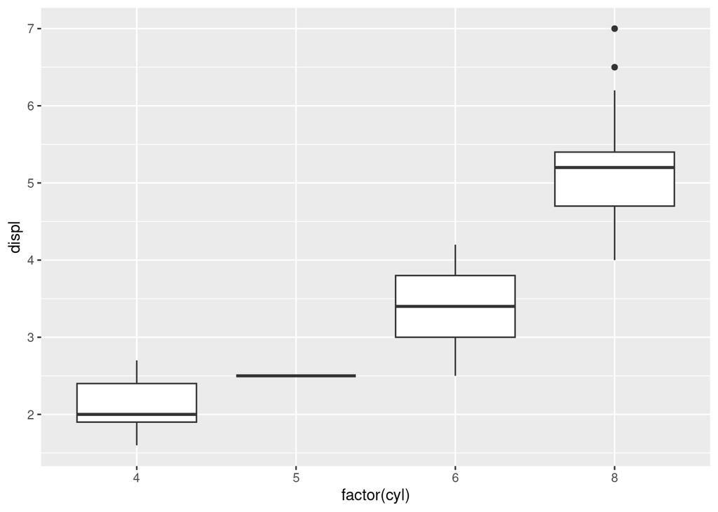

```r
ggplot(mpg, aes(x = factor(cyl), y = displ)) +
  geom_boxplot()
```